# Homework 2

Hajra Shahab; andrewID: hshahab

Fall 2020

```r
library(tidyverse)
```

### Problem 1: Tabular summaries

We’ll start by downloading a publicly available dataset that contains some census data information. This dataset is called `income`.

Here I’m using the `read_csv` command, which is the tidy version of `read.csv`. The resulting object is a `tibble`, which for the purposes of this question behaves exactly like a regular data frame.

```r
# Import data file
income <- read_csv("http://www.andrew.cmu.edu/user/achoulde/94842/data/income_data.txt",
                   col_names = FALSE)
# Give the variables names
colnames(income) <- c("age", "workclass", "fnlwgt",
                      "education", "education.years",
                      "marital.status", "occupation",
                      "relationship", "race", "sex",
                      "capital.gain", "capital.loss",
                      "hours.per.week", "native.country",
                      "income.bracket")
```

##### (a) table()

Use the `table()` function to produce a contingency table of observation counts across **marital status** and **sex**.

```r
table(income[c("marital.status", "sex")])
```

```
##                        sex
## marital.status          Female  Male
##   Divorced                2672  1771
##   Married-AF-spouse         14     9
##   Married-civ-spouse      1657 13319
##   Married-spouse-absent    205   213
##   Never-married           4767  5916
##   Separated                631   394
##   Widowed                  825   168
```

##### (b) The `prop.table()` function calculates a table of proportions from a table of counts. Read the documentation for this function to see how it works. Use `prop.table()` and your table from problem **(a)** to form a (column) proportions table. The Female column of the table should show the proportion of women in each marital status category. The Male column will show the same, but for men.

```r
marital.status.prop <- prop.table(table(income$marital.status, income$sex), margin = 2)
print(marital.status.prop)
```

```
##
##                               Female         Male
##   Divorced              0.2480735308 0.0812758146
##   Married-AF-spouse     0.0012997865 0.0004130335
##   Married-civ-spouse    0.1538390122 0.6112436898
##   Married-spouse-absent 0.0190325875 0.0097751262
##   Never-married         0.4425772909 0.2715006884
##   Separated             0.0585832328 0.0180816888
##   Widowed               0.0765945595 0.0077099587
```

##### (c) Use part (b) to answer the following questions. In this data set, are women more or less likely than men to be married? Are women more or less likely to be Widowed? (As part of your answer, calculate the % of individuals in each group who report being married, and the % who report being widowed. Use inline code chunks when reporting these values.)

**The percentage of women likely to be married is 17.42% while the percentage of men likely to be married is 62.14%. Hence we can conclude that women are less likely to be married. The percentage of women likely to be widowed is 7.66%. The percentage of men likely to be widowed is 0.77%. Hence we can conclude that women are more likely to be widowed.**

##### (d) group_by() and summarize()

Use the `summarize()` function in combination with `group_by()` to produce a table showing the average **education** (in years) across **marital status** and **sex** categories.

```r
income %>%
  group_by(marital.status, sex) %>%
  summarize (mean(education.years))
```

```
## # A tibble: 14 x 3
## # Groups:   marital.status [7]
##    marital.status        sex    `mean(education.years)`
##    <chr>                 <chr>                    <dbl>
##  1 Divorced              Female                   10.1
##  2 Divorced              Male                      9.97
##  3 Married-AF-spouse     Female                   10.1
##  4 Married-AF-spouse     Male                     10.2
##  5 Married-civ-spouse    Female                   10.4
##  6 Married-civ-spouse    Male                     10.3
##  7 Married-spouse-absent Female                    9.75
##  8 Married-spouse-absent Male                      8.88
##  9 Never-married         Female                   10.2
## 10 Never-married         Male                      9.79
## 11 Separated             Female                    9.21
## 12 Separated             Male                      9.42
## 13 Widowed               Female                    9.09
## 14 Widowed               Male                      9.10
```

### Problem 2: A more complex example: Bank Marketing Data

For the purpose of this problem we’ll be working with the Portuguese Bank Marketing data, which is described [at this link](https://archive.ics.uci.edu/ml/datasets/Bank+Marketing).

Each row of the data represents a different bank “client” or “customer”.

```r
bank.data <- read_delim("http://www.andrew.cmu.edu/user/achoulde/94842/data/bank-full.csv", delim = ";")
```

##### (a) Number of clients contacted by month.

Using `group_by` and `count`, produce a data frame that shows the number of clients who were contacted each month.

```r
bank.data %>%
  group_by(month) %>%
  count()
```

```
## # A tibble: 12 x 2
## # Groups:   month [12]
##    month     n
##    <chr> <int>
##  1 apr    2932
##  2 aug    6247
##  3 dec     214
##  4 feb    2649
##  5 jan    1403
##  6 jul    6895
##  7 jun    5341
##  8 mar     477
##  9 may   13766
## 10 nov    3970
## 11 oct     738
## 12 sep     579
```

##### (b) Changing levels of a factor.

You’ll notice that the months in your table above appear in alphabetical order. That makes it really hard to identify any meaningful temporal trends. Use the `mutate()` and `factor()` commands to relevel the month variable so that the levels appear in calendar order, from January (jan) to December (dec). You should replace the old `bank.data` data with your releveled version.

Once you’re done, repeat part (a).

You may want to look at the example [here](http://www.cookbook-r.com/Manipulating_data/Changing_the_order_of_levels_of_a_factor/).

```r
bank.data <- bank.data %>%
  mutate(month = factor(month,
                        levels = c("jan", "feb", "mar", "apr", "may", "jun", "jul", "aug", "sep", "oct", "nov", "dec")))
bank.data %>%
  group_by(month) %>%
  count()
```

```
## # A tibble: 12 x 2
## # Groups:   month [12]
##    month     n
##    <fct> <int>
##  1 jan    1403
##  2 feb    2649
##  3 mar     477
##  4 apr    2932
##  5 may   13766
##  6 jun    5341
##  7 jul    6895
##  8 aug    6247
##  9 sep     579
## 10 oct     738
## 11 nov    3970
## 12 dec     214
```

##### (c) Success rate by month

The `y` variable tells us whether the given client subscribed to a term deposit when contacted by the bank’s marketers. Use `group_by()` and `summarize()` to produce a table that shows for each month: the number of clients called (as in parts (a) and (b)), the number of clients who subscribed, and the proportion of clients who subscribed out of the number who were called. Note, if you want a count using `summarize()`, you may use the `n()` function within a `summarize()` call.

```r
bank.data %>%
  group_by(month) %>%
  summarize(client = n(), subscribers = (sum(y == "yes")), proportion = mean(y == "yes"))
```

```
## # A tibble: 12 x 4
##    month client subscribers proportion
##    <fct>  <int>       <int>      <dbl>
##  1 jan     1403         142     0.101
##  2 feb     2649         441     0.166
##  3 mar      477         248     0.520
##  4 apr     2932         577     0.197
##  5 may    13766         925     0.0672
##  6 jun     5341         546     0.102
##  7 jul     6895         627     0.0909
##  8 aug     6247         688     0.110
##  9 sep      579         269     0.465
## 10 oct      738         323     0.438
## 11 nov     3970         403     0.102
## 12 dec      214         100     0.467
```

##### (d) Variation in success of the marketing campaign

According to your analysis, which months were the most successful for the marketing campaign in terms of the fraction of contacted clients who subscribed?

The month of March followed by December, September and October respectively were the most successful for the marketing campaign in terms of the fraction of contacted clients who subscribed.

Are the more successful months the ones where the marketers tended to make more calls or fewer calls?

The most successful months are those where the marketers tended to make fewer calls. For instance, while March has the highest proportion of clients who subscribed, it has the second lowest number of calls across all months listed.

### Problem 3: Someone left strings in your numeric column!

This exercise will give you practice with two of the most common data cleaning tasks. For this problem we’ll use the `survey_untidy2020.csv` data set posted on the course website. Begin by importing this data into R. The url for the data set is shown below.

url: http://www.andrew.cmu.edu/user/achoulde/94842/data/survey_untidy2020.csv

In Lecture 4 we look at an example of cleaning up the TVhours column. The TVhours column of `survey_untidy2020.csv` has been corrupted in a similar way to what you saw in class.

Using the techniques you saw in class, make a new version of the untidy survey data where the TVhours column has been cleaned up. (Hint: *you may need to handle some of the observations on a case-by-case basis*)

```r
survey_untidy2020 <- read_csv("http://www.andrew.cmu.edu/user/achoulde/94842/data/survey_untidy2020.csv")
survey.recode<- mutate(survey_untidy2020,
                 TVhours = recode (TVhours,
                                   "no TV" = "0",
                                   "five" = "5",
                                   "zero" = "0",
                                   "two" = "2"))
survey <- mutate(survey.recode,
                 TVhours = as.numeric(gsub("[^0-9.]", "", TVhours)))
survey$TVhours
```

```
##  [1] 10.5  3.0  0.0 10.0  4.0  0.0  2.0 20.0  4.0  0.0 15.0  5.0 20.0 10.0  5.0
## [16]  2.0 14.0 10.0  4.0  3.0  6.0 10.0  2.0  3.0  3.0  1.0  1.0  3.0  5.0 10.0
## [31] 20.0  0.0  9.0  3.0  4.0  8.0  7.0  8.0 10.0 10.0  4.0 10.0  4.0  0.0  1.0
## [46]  7.0  2.0 15.0  8.0 10.0  2.0  3.0  4.0 21.0 10.0 20.0  0.0
```

### Problem 4: Shouldn’t ppm, pPM and PPM all be the same thing?

This exercise picks up from Problem 3, and walks you through two different approaches to cleaning up the Program column

##### (a) Identifying the problem.

Use the `table` or `count` command on the Program column to figure out what went wrong with this column. Describe the problem in the space below.

```r
table(survey[c("Program")])
```

```
##
##  mism  Mism  MISM other Other   ppm   Ppm   PPM
##     2     1     6     1     9     3     1    34
```

**Description of the problem:**

The problem is that data is split for PPM students among different str types whereas data for all PPM students should show in one row in a tabular form.

##### (b) `recode` approach

Starting with the cleaned up data you produced in Problem 3, use the `recode` and `mutate` functions to fix the Program column by mapping all of the lowercase and mixed case program names to upper case.

```r
survey.revised <- survey %>% mutate(Program = recode(Program, "ppm" = "PPM", "pPM" = "PPM", "mism" = "MISM", "Mism" = "MISM", "other" = "OTHER", "Other" = "OTHER"))
head(survey.revised, 8)
```

```
## # A tibble: 8 x 6
##   Program PriorExp          Rexperience       OperatingSystem TVhours Editor
##   <chr>   <chr>             <chr>             <chr>             <dbl> <chr>
## 1 PPM     Some experience   Never used        Windows            10.5 Other
## 2 OTHER   Extensive experi… Basic competence  Mac OS X            3   Microsoft…
## 3 MISM    Never programmed… Basic competence  Windows             0   Microsoft…
## 4 PPM     Never programmed… Never used        Windows            10   Excel
## 5 PPM     Never programmed… Never used        Windows             4   Microsoft…
## 6 PPM     Some experience   Basic competence  Mac OS X            0   Microsoft…
## 7 PPM     Never programmed… Never used        Mac OS X            2   Microsoft…
## 8 Ppm     Some experience   Installed on mac… Mac OS X           20   Other
```

##### (c) `toupper` approach

The `toupper` function takes an array of character strings and converts all letters to uppercase.

Use `toupper()` and `mutate` to perform the same data cleaning task as in part (b).

```r
survey.revised <- survey.revised %>% mutate(Program = toupper(Program))
print(survey.revised$Program)
```

```
##  [1] "PPM"   "OTHER" "MISM"  "PPM"   "PPM"   "PPM"   "PPM"   "PPM"   "PPM"
## [10] "OTHER" "PPM"   "PPM"   "PPM"   "PPM"   "PPM"   "PPM"   "PPM"   "MISM"
## [19] "MISM"  "PPM"   "PPM"   "OTHER" "PPM"   "PPM"   "OTHER" "OTHER" "OTHER"
## [28] "MISM"  "PPM"   "PPM"   "PPM"   "MISM"  "PPM"   "PPM"   "PPM"   "PPM"
## [37] "MISM"  "MISM"  "OTHER" "PPM"   "PPM"   "OTHER" "PPM"   "PPM"   "PPM"
## [46] "PPM"   "PPM"   "PPM"   "MISM"  "PPM"   "OTHER" "PPM"   "PPM"   "PPM"
## [55] "PPM"   "OTHER" "MISM"
```

**Tip**: *The `toupper()` and `tolower()` functions are very useful in data cleaning tasks. You may want to start by running these functions even if you’ll have to do some more spot-cleaning later on.*

### Problem 5: Let’s apply some functions

##### (a) Writing trimmed mean function

Write a function that calculates the mean of a numeric vector `x`, ignoring the `s` smallest and `l` largest values (this is a *trimmed mean*).

E.g., if `x = c(1, 7, 3, 2, 5, 0.5, 9, 10)`, `s = 1`, and `l = 2`, your function would return the mean of `c(1, 7, 3, 2, 5)` (this is `x` with the 1 smallest value (0.5) and the 2 largest values (9, 10) removed).

Your function should use the `length()` function to check if `x` has at least `s + l + 1` values. If `x` is shorter than `s + l + 1`, your function should use the `message()` function to tell the user that the vector can’t be trimmed as requested. If `x` is at least length `s + l + 1`, your function should return the trimmed mean.

```r
trimmedMean <- function(x, s = 0, l = 0)
  if( length(x) < (s + l + 1)) {
    message("vector cannot be trimmed")
  } else if( length(x) >= (s + l + 1)) {
    x <- sort(x)
    x <- x[-1:-s]
    x <- sort(x, decreasing = TRUE)
    x <- x [-1: -l]
    mean(x)}
```

**Hint:** *For this exercise it will be useful to recall the `sort()` function that you first saw in Lecture 1.*

**Note:** The `s = 0` and `l = 0` specified in the function definition are the default settings. i.e., this syntax ensures that if `s` and `l` are not provided by the user, they are both set to `0`. Thus the default behaviour is that the `trimmedMean` function doesn’t trim anything, and hence is the same as the `mean` function.

##### (b) Apply your function with a for loop

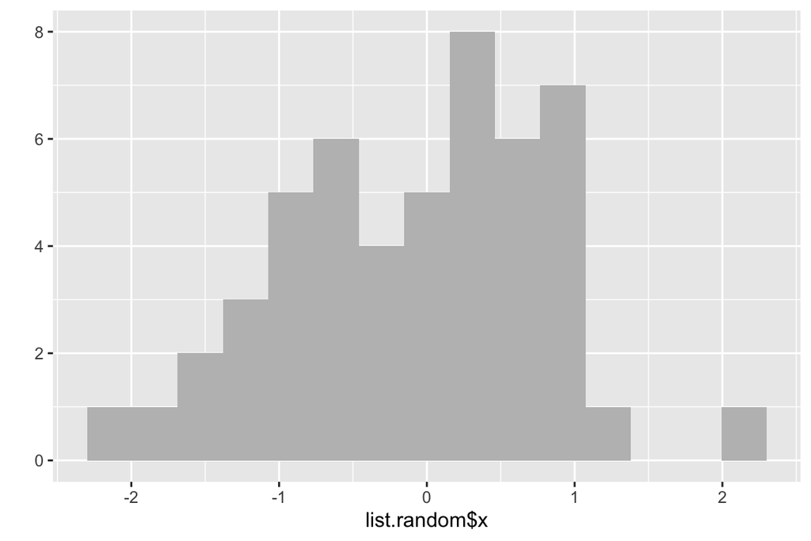

```r
set.seed(201911)
list.random <- list(x = rnorm(50),
                    y = rexp(65),
                    z = rt(100, df = 1.5))

#Here are the histograms of the data

qplot(list.random$x, bins = 15, fill = I('grey'))
```

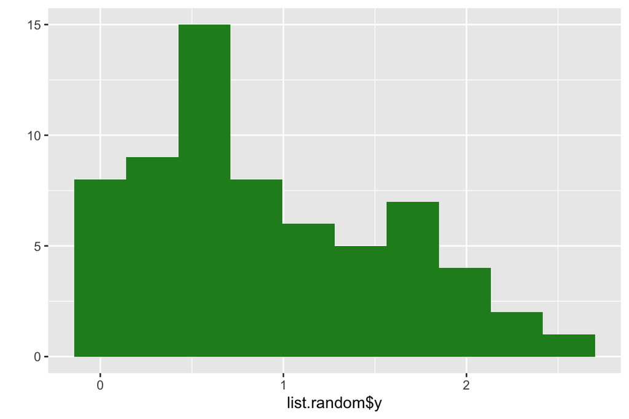

```r
qplot(list.random$y, bins = 10, fill = I('forestgreen'))
```

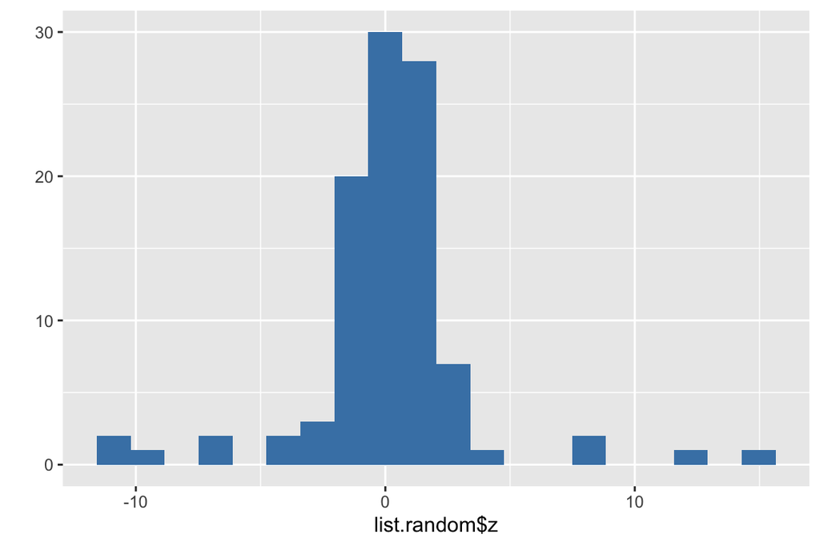

```r
qplot(list.random$z, bins = 20, fill = I('steelblue'))
```

Using a `for loop` and your function from part **(a)**, create a vector whose elements are the trimmed means of the vectors in `list.random`, taking `s = 5` and `l = 5`.

```r
list.trimmedMean <- c()
for (i in list.random){
  list.trimmedMean <- append(list.trimmedMean, round(trimmedMean(i, 5, 5), 3))
}
print(list.trimmedMean)
```

```
## [1] -0.043  0.882  0.081
```

##### (c) Calculate the un-trimmed means for each of the vectors in the list. How do these compare to the trimmed means you calculated in part (b)? Explain your findings.

```r
#round it off?
list.mean <- c()
for( i in list.random){
  list.mean <- append(list.mean, round(mean(i), 3))
}
print(list.mean)
```

```
## [1] -0.081  0.926  0.110
```

**Explanation:**

#double check There is a difference between the trimmed and untrimmed means. We can conclude that x is left skewed, y is right skewed , z has outliers.

##### (d) `map` functions

Repeat part **(b)**, using the `map` and `map_dbl` functions instead of a for loop. Your `map` command should return a list of trimmed means, and your `map_dbl` command should return a numeric vector of trimmed means.

```r
map(list.random, trimmedMean, s = 5, l = 5)
```

```
## $x
## [1] -0.0427887
##
## $y
## [1] 0.8820237
##
## $z
## [1] 0.08098954
```

```r
map_dbl(list.random, trimmedMean, s = 5, l = 5)
```

```
##           x           y           z
## -0.04278870  0.88202374  0.08098954
```

**Hint** `map` and other functions can take arguments that you wish to pass to the `trimmedMean` function. E.g., if you were applying the function `sort`, which has an argument `decreasing`, you could use the syntax `map(..., .f = sort, decreasing = TRUE)`.